# Preliminary Analysis

Ebba Mark

2023-07-02

# County-level data scoping

This document explores the county-level data for completeness and other issues.

# Plotting Totals

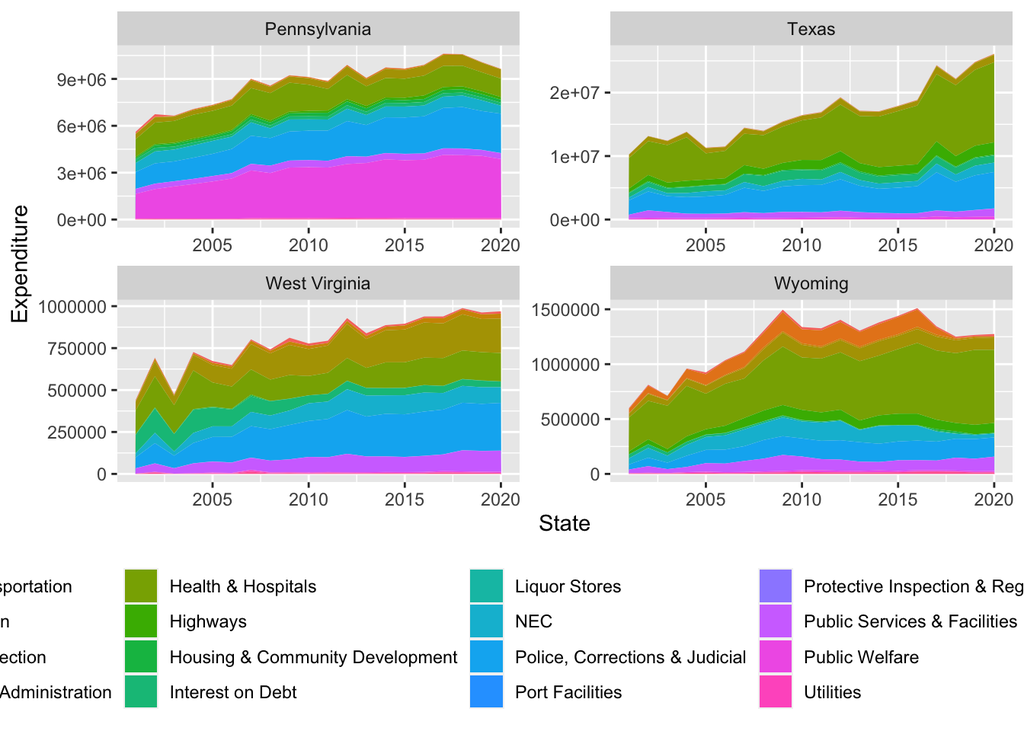

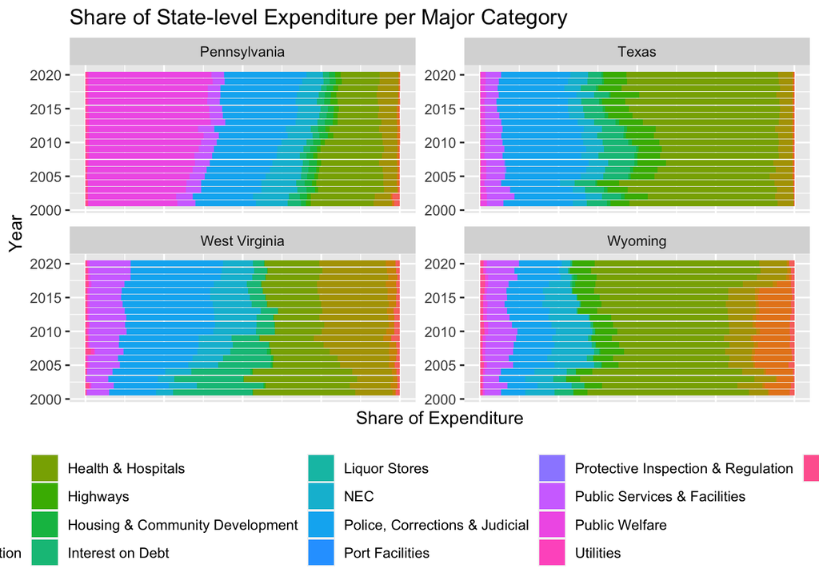

# Simple time trends and TWFE regressions

Standard linear time trends evaluated in state-fixed effects panel linear regression model from 2000-2020.

# Time Trends with Linear Interpolation

Time Trends

TWFE w. GDP Control

Outcome Variable

Interest On Debt

0***

0***

0*

0

0

0

0

Protective Inspection Regulation

0

0**

0*

0**

0

0

0

0

Liquor Stores

0***

0***

0***

0***

0

0

0

0

Port Facilities

0

0**

0

0

0

0

0

0

Housing Community Development

0***

0***

0

0***

0

0

0

0

Air Transportation

0***

0***

0

0

0

0

0

0

Utilities

0***

0***

0

0

0

0

0

0

Fire Protection

0***

0***

0

0

0

0

0

0

Waste Management Sewerage

0***

0***

0

0

0

0

0

0

Public Welfare

0***

0***

0*

0

0

0

0

0

Public Services Facilities

0***

0***

0

0

0

0

0

0

Health Hospitals

0***

0***

0***

0***

0

0

0

0

General Administration

0***

0***

0***

0***

0

0

0

0

Education

0***

0***

0*

0**

0

0

0

0

Nec

0***

0***

0

0

0

0

0

0

Highways

0.01***

0.01***

0**

0***

0

0

0

0

Police Corrections Judicial

0.01***

0.01***

0**

0***

0

0

0

0

# Totals

```
## NOTE: 20,431 observations removed because of NA values (LHS: 20,431).
```

```
## NOTE: 20,431 observations removed because of NA values (LHS: 20,431, RHS: 20,431).
## NOTE: 20,431 observations removed because of NA values (LHS: 20,431, RHS: 20,431).
## NOTE: 20,431 observations removed because of NA values (LHS: 20,431, RHS: 20,431).
```

# Plot 1

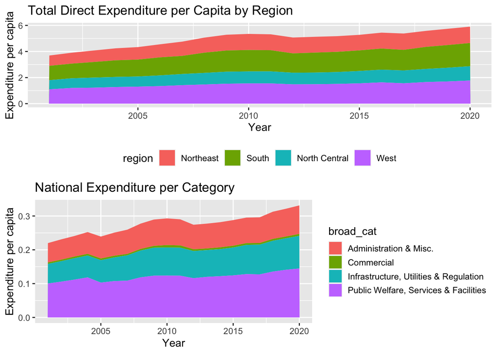

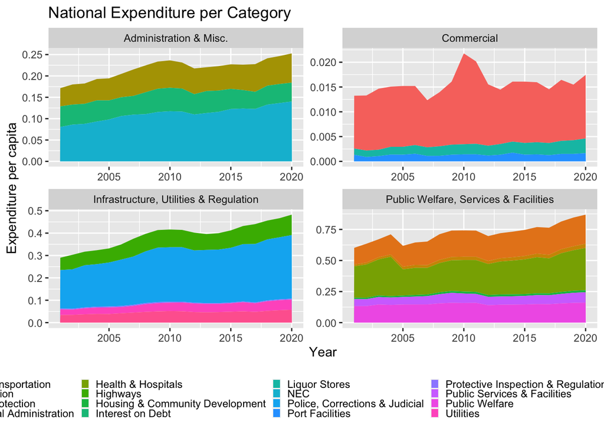

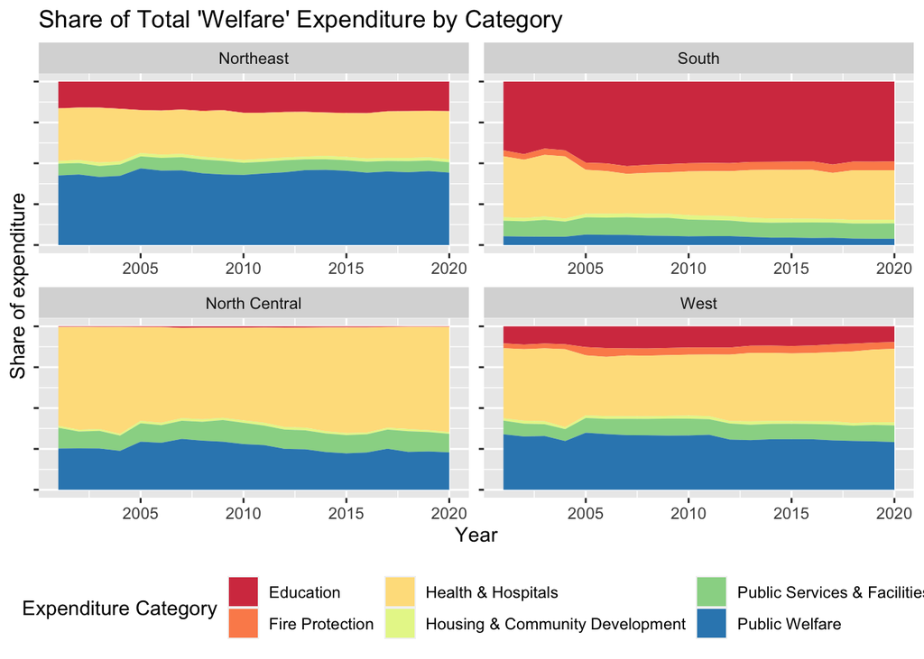

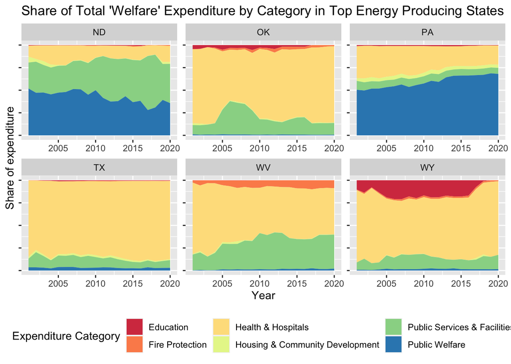